# Untitled7-Copy2

```python
import pandas as pd
import numpy as np
import matplotlib.pyplot as plt
import seaborn as sns
```

```python
df = pd.read_csv('/Users/nischaljain/Downloads/sydney_rain prediction1.csv',header=0)
df.head()
```

|  | Date | Location | MinTemp | MaxTemp | Rainfall | Evaporation | Sunshine | Humidity9am | Humidity3pm | Pressure9am | Pressure3pm | Cloud9am | Cloud3pm | Temp9am | Temp3pm | RainToday | RainTomorrow |
| --- | --- | --- | --- | --- | --- | --- | --- | --- | --- | --- | --- | --- | --- | --- | --- | --- | --- |
| 0 | 01/02/08 | Sydney | 19.5 | 22.4 | 15.6 | 6.2 | 0.0 | 92.0 | 84.0 | 1017.6 | 1017.4 | 8.0 | 8.0 | 20.7 | 20.9 | Yes | Yes |
| 1 | 02/02/08 | Sydney | 19.5 | 25.6 | 6.0 | 3.4 | 2.7 | 83.0 | 73.0 | 1017.9 | 1016.4 | 7.0 | 7.0 | 22.4 | 24.8 | Yes | Yes |
| 2 | 03/02/08 | Sydney | 21.6 | 24.5 | 6.6 | 2.4 | 0.1 | 88.0 | 86.0 | 1016.7 | 1015.6 | 7.0 | 8.0 | 23.5 | 23.0 | Yes | Yes |
| 3 | 04/02/08 | Sydney | 20.2 | 22.8 | 18.8 | 2.2 | 0.0 | 83.0 | 90.0 | 1014.2 | 1011.8 | 8.0 | 8.0 | 21.4 | 20.9 | Yes | Yes |
| 4 | 05/02/08 | Sydney | 19.7 | 25.7 | 77.4 | NaN | 0.0 | 88.0 | 74.0 | 1008.3 | 1004.8 | 8.0 | 8.0 | 22.5 | 25.5 | Yes | Yes |

```python
df.describe()
```

|  | MinTemp | MaxTemp | Rainfall | Evaporation | Sunshine | Humidity9am | Humidity3pm | Pressure9am | Pressure3pm | Cloud9am | Cloud3pm | Temp9am | Temp3pm |
| --- | --- | --- | --- | --- | --- | --- | --- | --- | --- | --- | --- | --- | --- |
| count | 3334.000000 | 3335.000000 | 3331.000000 | 3286.000000 | 3321.000000 | 3323.000000 | 3324.000000 | 3317.000000 | 3318.000000 | 2771.000000 | 2776.000000 | 3333.000000 | 3333.000000 |
| mean | 14.865057 | 23.002339 | 3.330231 | 5.187432 | 7.179374 | 68.229010 | 54.699158 | 1018.346156 | 1016.018774 | 4.181523 | 4.218660 | 17.819742 | 21.533333 |
| std | 4.553641 | 4.494638 | 9.895172 | 2.777407 | 3.810886 | 15.085355 | 16.293530 | 7.021571 | 7.032211 | 2.749578 | 2.641885 | 4.897177 | 4.303737 |
| min | 4.300000 | 11.700000 | 0.000000 | 0.000000 | 0.000000 | 19.000000 | 10.000000 | 986.700000 | 989.800000 | 0.000000 | 0.000000 | 6.400000 | 10.200000 |
| 25% | 11.000000 | 19.600000 | 0.000000 | 3.200000 | 4.300000 | 58.000000 | 44.000000 | 1013.700000 | 1011.300000 | 1.000000 | 1.000000 | 13.800000 | 18.400000 |
| 50% | 14.900000 | 22.800000 | 0.000000 | 4.800000 | 8.300000 | 69.000000 | 56.000000 | 1018.600000 | 1016.300000 | 5.000000 | 4.000000 | 18.200000 | 21.300000 |
| 75% | 18.700000 | 26.000000 | 1.400000 | 7.000000 | 10.200000 | 80.000000 | 65.000000 | 1023.100000 | 1020.800000 | 7.000000 | 7.000000 | 21.700000 | 24.500000 |
| max | 27.600000 | 45.800000 | 119.400000 | 18.400000 | 13.600000 | 100.000000 | 99.000000 | 1039.000000 | 1036.700000 | 9.000000 | 8.000000 | 36.500000 | 44.700000 |

```python
df.shape
```

```
(3337, 17)
```

```python
df.info()
```

```
<class 'pandas.core.frame.DataFrame'>
RangeIndex: 3337 entries, 0 to 3336
Data columns (total 17 columns):
 #   Column        Non-Null Count  Dtype
---  ------        --------------  -----
 0   Date          3337 non-null   object
 1   Location      3337 non-null   object
 2   MinTemp       3334 non-null   float64
 3   MaxTemp       3335 non-null   float64
 4   Rainfall      3331 non-null   float64
 5   Evaporation   3286 non-null   float64
 6   Sunshine      3321 non-null   float64
 7   Humidity9am   3323 non-null   float64
 8   Humidity3pm   3324 non-null   float64
 9   Pressure9am   3317 non-null   float64
 10  Pressure3pm   3318 non-null   float64
 11  Cloud9am      2771 non-null   float64
 12  Cloud3pm      2776 non-null   float64
 13  Temp9am       3333 non-null   float64
 14  Temp3pm       3333 non-null   float64
 15  RainToday     3331 non-null   object
 16  RainTomorrow  3337 non-null   object
dtypes: float64(13), object(4)
memory usage: 443.3+ KB
```

```python
df = df.drop(["Evaporation","Sunshine","Cloud9am","Cloud3pm","Location", "Date"], axis =1)
df.head()
```

|  | MinTemp | MaxTemp | Rainfall | Humidity9am | Humidity3pm | Pressure9am | Pressure3pm | Temp9am | Temp3pm | RainToday | RainTomorrow |
| --- | --- | --- | --- | --- | --- | --- | --- | --- | --- | --- | --- |
| 0 | 19.5 | 22.4 | 15.6 | 92.0 | 84.0 | 1017.6 | 1017.4 | 20.7 | 20.9 | Yes | Yes |
| 1 | 19.5 | 25.6 | 6.0 | 83.0 | 73.0 | 1017.9 | 1016.4 | 22.4 | 24.8 | Yes | Yes |
| 2 | 21.6 | 24.5 | 6.6 | 88.0 | 86.0 | 1016.7 | 1015.6 | 23.5 | 23.0 | Yes | Yes |
| 3 | 20.2 | 22.8 | 18.8 | 83.0 | 90.0 | 1014.2 | 1011.8 | 21.4 | 20.9 | Yes | Yes |
| 4 | 19.7 | 25.7 | 77.4 | 88.0 | 74.0 | 1008.3 | 1004.8 | 22.5 | 25.5 | Yes | Yes |

```python
df = df.dropna(axis = 0)
df.shape
```

```
(3286, 11)
```

```python
#convert string to numerical values
from sklearn.preprocessing import LabelEncoder
le = LabelEncoder()
df['RainToday'] = le.fit_transform(df['RainToday'])
df['RainTomorrow'] = le.fit_transform(df['RainTomorrow'])
```

```python
#now we will divide the dataset into dependent(X) and independent(Y) variable
x = df.drop(['RainTomorrow'], axis = 1)
y = df['RainTomorrow']
```

```python
x.head()
```

|  | MinTemp | MaxTemp | Rainfall | Humidity9am | Humidity3pm | Pressure9am | Pressure3pm | Temp9am | Temp3pm | RainToday |
| --- | --- | --- | --- | --- | --- | --- | --- | --- | --- | --- |
| 0 | 19.5 | 22.4 | 15.6 | 92.0 | 84.0 | 1017.6 | 1017.4 | 20.7 | 20.9 | 1 |
| 1 | 19.5 | 25.6 | 6.0 | 83.0 | 73.0 | 1017.9 | 1016.4 | 22.4 | 24.8 | 1 |
| 2 | 21.6 | 24.5 | 6.6 | 88.0 | 86.0 | 1016.7 | 1015.6 | 23.5 | 23.0 | 1 |
| 3 | 20.2 | 22.8 | 18.8 | 83.0 | 90.0 | 1014.2 | 1011.8 | 21.4 | 20.9 | 1 |
| 4 | 19.7 | 25.7 | 77.4 | 88.0 | 74.0 | 1008.3 | 1004.8 | 22.5 | 25.5 | 1 |

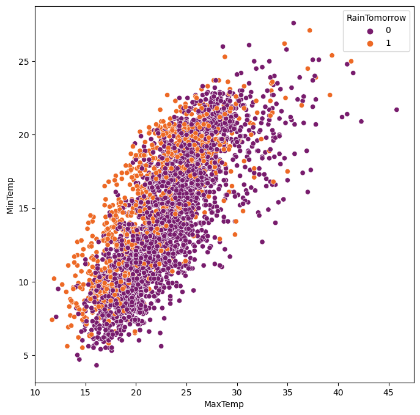

```python
#now will draw scatter-plot using seaborn library
plt.figure(figsize = (8,8))
sns.scatterplot(x = 'MaxTemp', y = 'MinTemp', hue = 'RainTomorrow' , palette = 'inferno',data = df)
```

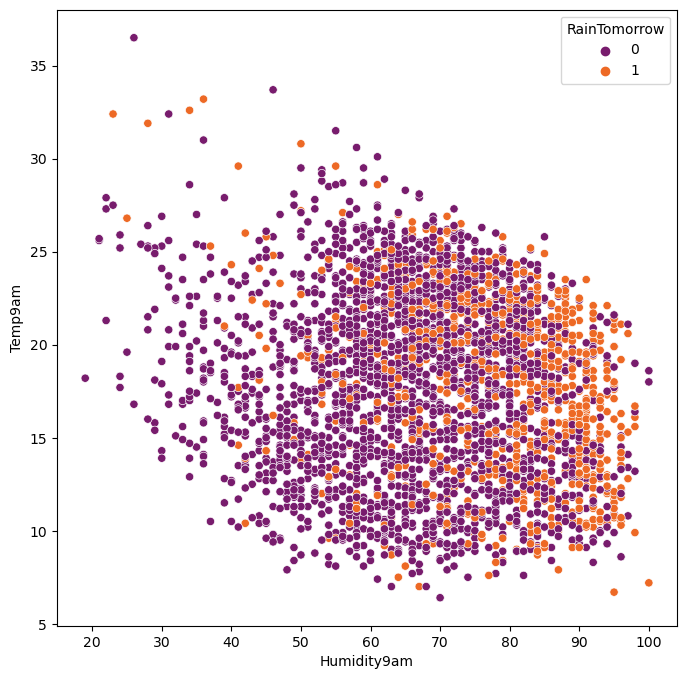

```python
plt.figure(figsize = (8,8))
sns.scatterplot(x = 'Humidity9am', y = 'Temp9am', hue = 'RainTomorrow' , palette = 'inferno',data = df)
```

```python
#now i will split the data into traning and testing
from sklearn.model_selection import train_test_split
x_train, x_test, y_train, y_test = train_test_split(x,y, test_size = 0.2)
```

```python
# now i will import classification report,confusion matrix and accuracy score
from sklearn.metrics import classification_report, confusion_matrix, accuracy_score
```

# logistic Regression

```python
from sklearn.linear_model import LogisticRegression
lr = LogisticRegression()
lr.fit(x_train,y_train)
predictions = lr.predict(x_test)
print(confusion_matrix(y_test, predictions))
print(classification_report(y_test, predictions))
print(accuracy_score(y_test, predictions))
```

```
[[472  29]
 [ 81  76]]
              precision    recall  f1-score   support

           0       0.85      0.94      0.90       501
           1       0.72      0.48      0.58       157

    accuracy                           0.83       658
   macro avg       0.79      0.71      0.74       658
weighted avg       0.82      0.83      0.82       658

0.8328267477203647
```

# Decision Tree

```python
from sklearn.tree import DecisionTreeClassifier
dt = DecisionTreeClassifier()
dt.fit(x_train,y_train)
predictions = dt.predict(x_test)
print(confusion_matrix(y_test, predictions))
print(classification_report(y_test, predictions))
print(accuracy_score(y_test, predictions))
```

```
[[416  85]
 [ 76  81]]
              precision    recall  f1-score   support

           0       0.85      0.83      0.84       501
           1       0.49      0.52      0.50       157

    accuracy                           0.76       658
   macro avg       0.67      0.67      0.67       658
weighted avg       0.76      0.76      0.76       658

0.7553191489361702
```

# Random Forest Classifier

```python
from sklearn.ensemble import RandomForestClassifier
rf = RandomForestClassifier()
rf.fit(x_train,y_train)
predictions = rf.predict(x_test)
print(confusion_matrix(y_test, predictions))
print(classification_report(y_test, predictions))
print(accuracy_score(y_test, predictions))
```

```
[[460  41]
 [ 73  84]]
              precision    recall  f1-score   support

           0       0.86      0.92      0.89       501
           1       0.67      0.54      0.60       157

    accuracy                           0.83       658
   macro avg       0.77      0.73      0.74       658
weighted avg       0.82      0.83      0.82       658

0.8267477203647416
```

Q1)Your views about the problem statement? ans: In this problem statement I have to predicted the rainfall using various model like logistic Regression,Decision Tree,Random Forest Classifier.

Q2) What will be your approach to solving this task? Ans: Step-1 Importing all the neccessary library like pandas,numpy and seaborn step 2 cleaning the data like dropping null and missing values step3 visualising the data using scatter plot step4. finding accuracy score,classificatio report and confusion matrix using various models like logistic. regression,decision tree and. Random forest classifier

Q4). Which model’s performance is best and what could be the possible reason for that? Ans: Logistic regression model's perfomance is best because it is predicting better than other models.

Q5) What steps can you take to improve this selected model’s performance even further? Ans: i)By choosing a robust algorithm: Choosing the right algorithm is dependent on: -The specific requirements of your model. -The type of data you are working with. -The problem you are trying to solve.

ii)Improve Model : This step is crucial in achieving an improved model and its quality.

iii)Ensemble Learning :By mixing the predictions from various models, ensemble learning is a broad meta-approach to machine learning that aims to improve model performance.